# Model performance for Model Level Explanations

Code snippets for R

Przemysław Biecek

for DALEX 1.0

In this section, we use an `DALEX::model_performance()` function for calculation of various model performance measures.

If you want learn more about mathematical formations of these measures read https://pbiecek.github.io/ema/modelPerformance.html.

Note that there are also other R packages that offer similar functionality, like `mlr`.

# Prepare data

For classification example we will use the titanic data. It has few variables that are easy to understand. The `titanic_imputed` dataset from `DALEX` package has imputed missing values. Find more about the data https://pbiecek.github.io/ema/dataSetsIntro.html#TitanicDataset

```r
library("DALEX")
head(titanic_imputed)
```

```
##   gender age class    embarked  fare sibsp parch survived
## 1   male  42   3rd Southampton  7.11     0     0        0
## 2   male  13   3rd Southampton 20.05     0     2        0
## 3   male  16   3rd Southampton 20.05     1     1        0
## 4 female  39   3rd Southampton 20.05     1     1        1
## 5 female  16   3rd Southampton  7.13     0     0        1
## 6   male  25   3rd Southampton  7.13     0     0        1
```

# Train models

Here we use `ranger` library to train a classification random forest model and `rms` model to train a logistic regression model with splines.

```r
library("ranger")
titanic_rf <- ranger(survived ~ class + gender + age + sibsp +
         parch + fare + embarked, data = titanic_imputed,
         probability = TRUE,
         classification = TRUE)
titanic_rf
```

```
## Ranger result
##
## Call:
##  ranger(survived ~ class + gender + age + sibsp + parch + fare +      embarked, data = titanic_imputed, probability = TRUE, classification = TRUE)
##
## Type:                             Probability estimation
## Number of trees:                  500
## Sample size:                      2207
## Number of independent variables:  7
## Mtry:                             2
## Target node size:                 10
## Variable importance mode:         none
## Splitrule:                        gini
## OOB prediction error (Brier s.):  0.1417578
```

```r
library("rms")
titanic_lmr <- lrm(survived ~ gender + rcs(age) + class +
         sibsp + parch + fare + embarked, titanic_imputed)
```

# Prepare an explainer

Different models have different structures. We use `DALEX::explain()` function to create an uniform interface for the model

```r
library("DALEX")
titanic_ex <- explain(titanic_rf,
                data  = titanic_imputed,
                y     = titanic_imputed$survived,
                label = "Regression Forest for Titanic",
                verbose = FALSE)

titanic_ex_lmr <- explain(titanic_lmr,
                data  = titanic_imputed,
                y     = titanic_imputed$survived,
                label = "Logistic regression with splines",
                verbose = FALSE)
titanic_ex_lmr$model_info$type = "classification"
```

# Model performance for classification models with `model_performance()`

The `DALEX::model_performance()` function calculates the most popular model measures. This function expects two arguments

- the model explainer,
- `cutoff` with the cutoff for measures that work on binary classifications rather than scores.

As a result, the function yields an object of the class `model_performance`. It is a data frame with model performance measures

- recall, also known as sensitivity,
- precision, also called positive predictive value,
- f1 score is the harmonic mean of precision and recall,
- accuracy is the fraction of correct responses,
- auc area under the curve.

```
## Measures for:  classification
## recall   : 0.5935302
## precision: 0.8997868
## f1       : 0.7152542
## accuracy : 0.8477571
## auc      : 0.9015669
##
## Residuals:
##          0%         10%         20%         30%         40%         50%
## -0.79379781 -0.24126441 -0.20633474 -0.18084408 -0.16549658 -0.12733954
##         60%         70%         80%         90%        100%
## -0.09437398  0.02898832  0.22677999  0.60102454  0.88265147
```

```
## Measures for:  classification
## recall   : 0.5850914
## precision: 0.7522604
## f1       : 0.6582278
## accuracy : 0.8042592
## auc      : 0.81741
##
## Residuals:
##          0%         10%         20%         30%         40%         50%
## -0.98457244 -0.31904861 -0.23408037 -0.20311483 -0.15200813 -0.10318060
##         60%         70%         80%         90%        100%
## -0.06933478  0.05858024  0.29306442  0.73666519  0.97151255
```

Model performance measure may be supplemented with graphical summary, like ROC curve.

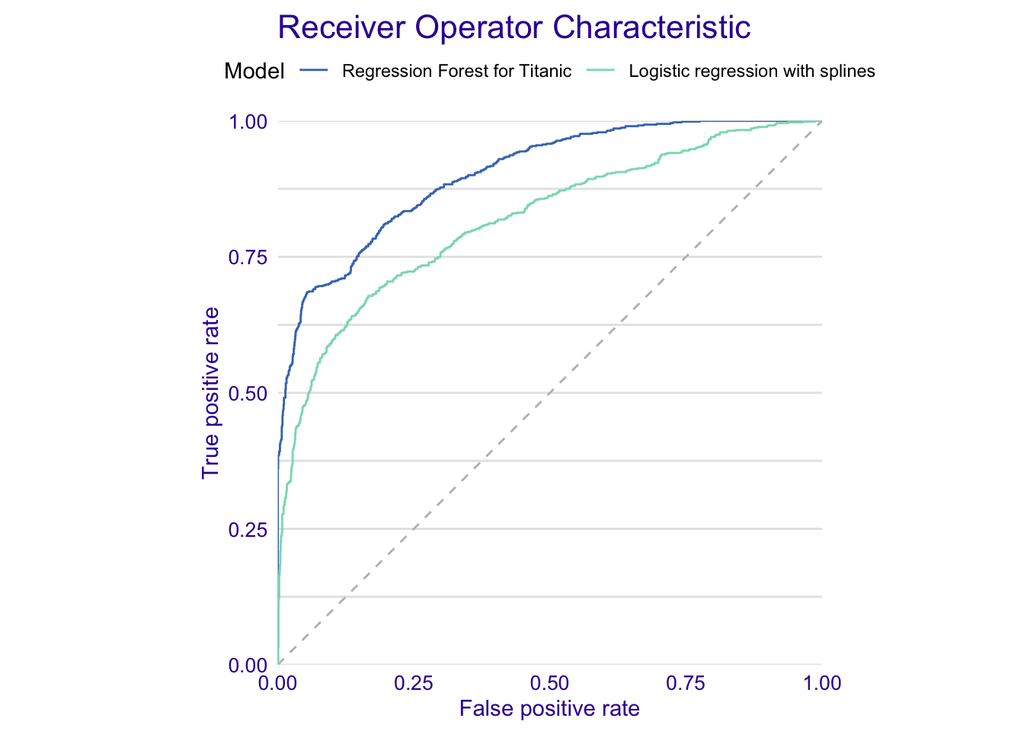

```r
plot(titanic_mp, titanic_mp_lmr, geom = "roc")
```

Or the lift curve.

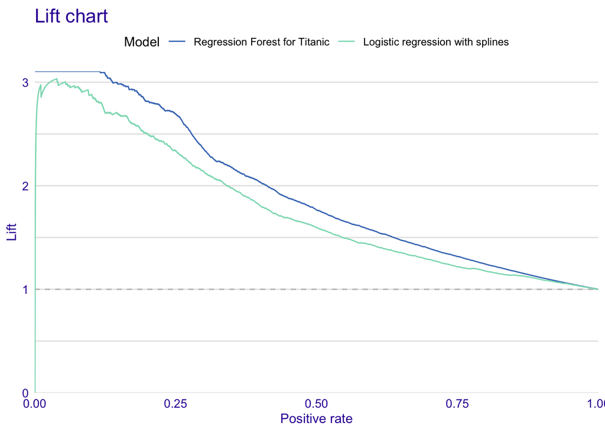

```r
plot(titanic_mp, titanic_mp_lmr, geom = "lift")
```

Or the gain curve.

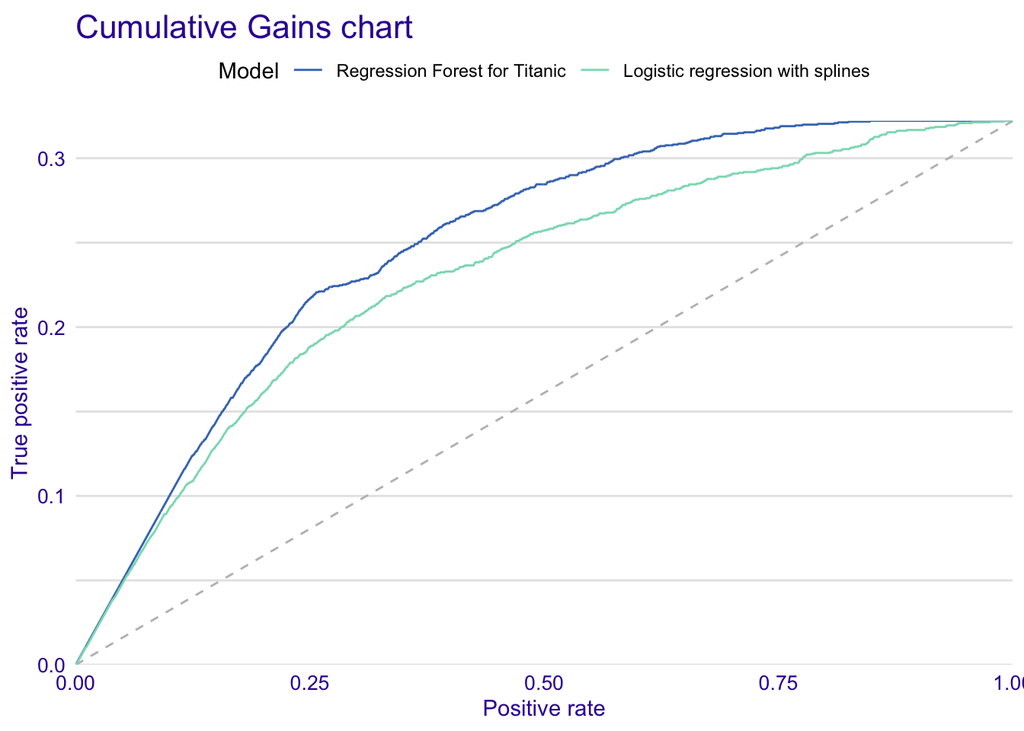

```r
plot(titanic_mp, titanic_mp_lmr, geom = "gain")
```

Or boxplot

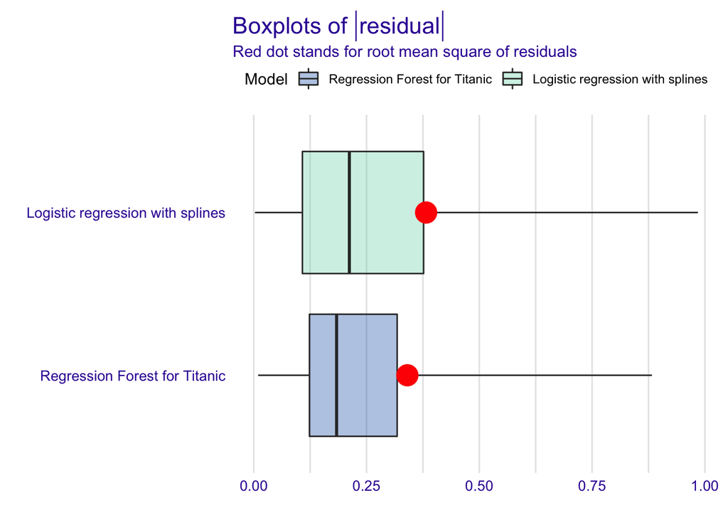

```r
plot(titanic_mp, titanic_mp_lmr, geom = "boxplot")
```

Or histogram

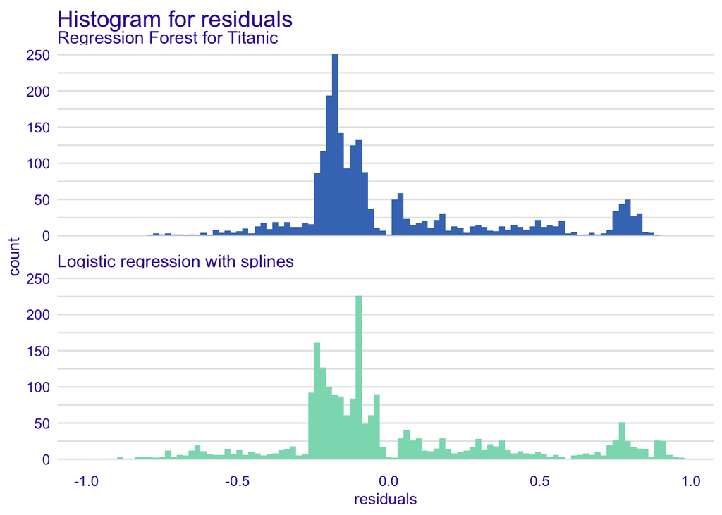

```r
plot(titanic_mp, titanic_mp_lmr, geom = "histogram")
```

# Prepare data

For regression example we will use the `apartments` data from `DALEX` package. It has few variables that are easy to understand. Find more about the data https://pbiecek.github.io/ema/dataSetsIntro.html#ApartmentDataset

```r
library("DALEX")
head(apartments)
```

```
##   m2.price construction.year surface floor no.rooms    district
## 1     5897              1953      25     3        1 Srodmiescie
## 2     1818              1992     143     9        5     Bielany
## 3     3643              1937      56     1        2       Praga
## 4     3517              1995      93     7        3      Ochota
## 5     3013              1992     144     6        5     Mokotow
## 6     5795              1926      61     6        2 Srodmiescie
```

# Train models

We will use two models in this example. A simple linear model trained with `lm()` function and random forest model trained with `randomForest()` function.

```r
set.seed(13)

apartments_lm <- lm(m2.price ~ ., data = apartments)
anova(apartments_lm)
```

```
## Analysis of Variance Table
##
## Response: m2.price
##                    Df    Sum Sq   Mean Sq  F value    Pr(>F)
## construction.year   1   2629802   2629802   33.233 1.093e-08 ***
## surface             1 207840733 207840733 2626.541 < 2.2e-16 ***
## floor               1  79823027  79823027 1008.746 < 2.2e-16 ***
## no.rooms            1    956996    956996   12.094  0.000528 ***
## district            9 451993980  50221553  634.664 < 2.2e-16 ***
## Residuals         986  78023123     79131
## ---
## Signif. codes:  0 '***' 0.001 '**' 0.01 '*' 0.05 '.' 0.1 ' ' 1
```

```r
library("randomForest")
apartments_rf <- randomForest(m2.price ~ ., data = apartments)
apartments_rf
```

```
##
## Call:
##  randomForest(formula = m2.price ~ ., data = apartments)
##                Type of random forest: regression
##                      Number of trees: 500
## No. of variables tried at each split: 1
##
##           Mean of squared residuals: 82063.51
##                     % Var explained: 90.01
```

# Prepare explainers

Different models have different structures. We use `DALEX::explain()` function to create an uniform interface for the model

```r
library("DALEX")
explain_lm <- explain(model = apartments_lm,
         data = apartments_test,
         y = apartments_test$m2.price,
         label = "Linear Regression for apartments",
         verbose = FALSE)

explain_rf <- explain(model = apartments_rf,
         data = apartments_test,
         y = apartments_test$m2.price,
         label = "Random Forest for apartments",
         verbose = FALSE)
```

# Model performance for regression models with `model_performance()`

The `DALEX::model_performance()` function calculates the most popular model measures. The only expected argument is the model explainer. As a result, the function yields an object of the class `model_performance`.

It is a data frame with selected model performance measures

- mean square error,
- root mean square error,
- median absolute deviation,
- R-square coefficient.

```
## Measures for:  regression
## mse      : 80137.98
## rmse     : 283.0865
## r2       : 0.9011624
## mad      : 212.7067
##
## Residuals:
##        0%       10%       20%       30%       40%       50%       60%       70%
## -257.2555 -221.4659 -209.2460 -195.8834 -184.1412 -174.0677 -161.2473  370.8841
##       80%       90%      100%
##  398.2811  423.9131  472.3560
```

```
## Measures for:  regression
## mse      : 80588.4
## rmse     : 283.881
## r2       : 0.9006069
## mad      : 172.4773
##
## Residuals:
##          0%         10%         20%         30%         40%         50%
## -742.458887 -288.967993 -217.200951 -159.631034 -110.595983  -57.541678
##         60%         70%         80%         90%        100%
##    7.203613   89.478920  203.147867  397.666209 1299.033740
```

Both plots can be supplemented with boxplots for residuals. Toward this end, the residuals have got to be computed and added to the explainer object with the help of the `model_performance()` function. Subsequently, the `plot()` can be applied to the resulting object.

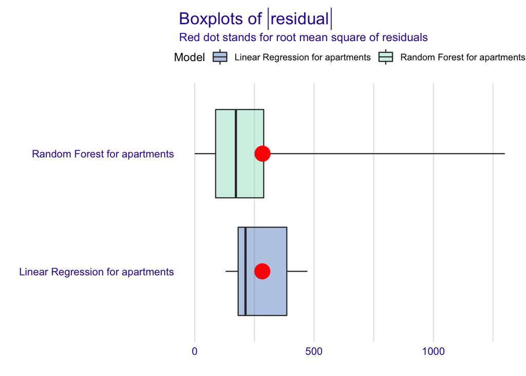

```r
plot(apartments_mp, apartments_mp_rf, geom = "boxplot")
```

And the histogram.

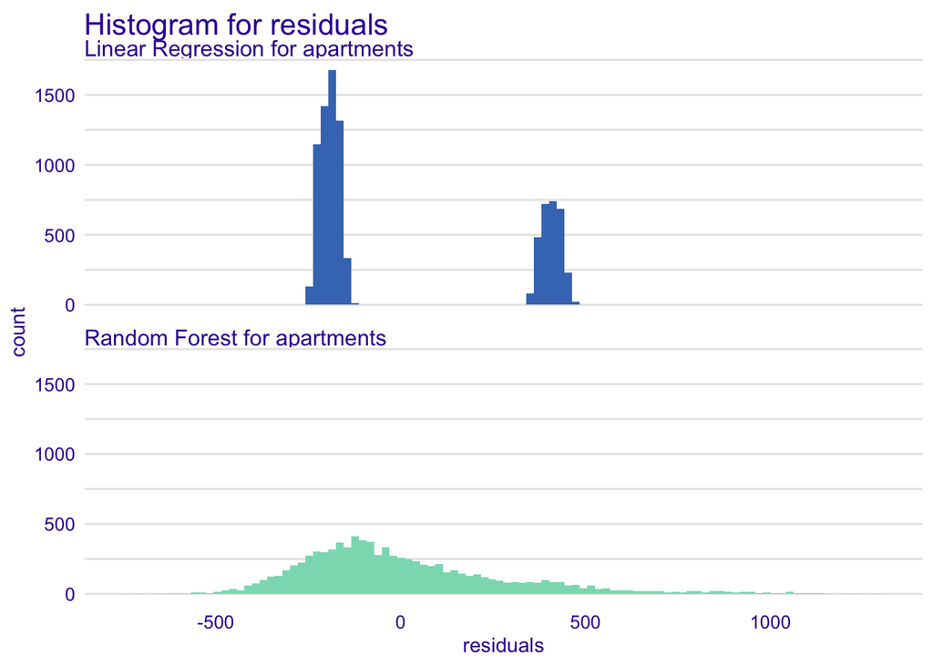

```r
plot(apartments_mp, apartments_mp_rf, geom = "histogram")
```